## General features of the dataset

### ASSIST dataset

We are going to analyse a subset of a data set from ASSIST (Approaches and Study Skills Inventory for Students) study which in its’ raw format can be found [here](https://www.mv.helsinki.fi/home/kvehkala/JYTmooc/JYTOPKYS3-data.txt). The study was on evaluating different learning approaches in students. The different learning methods covered were **DEEP** learning **STRA**tegic learning and **SURF**ace learning (*bolded sections of the learning methods represent the variable name in the dataset which is loaded below*; students2014).

```r
# Read file that was wrangled
students2014 <- read.delim("Data/learning2014.tsv", header = T, sep = "\t")

# Structure and dimensions
str(students2014)
```

```
## 'data.frame':    166 obs. of  7 variables:
##  $ gender  : chr  "F" "M" "F" "M" ...
##  $ age     : int  53 55 49 53 49 38 50 37 37 42 ...
##  $ attitude: int  39 33 33 37 35 38 37 37 34 29 ...
##  $ deep    : num  3.58 2.92 3.5 3.5 3.67 ...
##  $ stra    : num  3.38 2.75 3.62 3.12 3.62 ...
##  $ surf    : num  2.58 3.17 2.25 2.25 2.83 ...
##  $ points  : int  25 12 24 10 22 21 21 31 24 26 ...
```

```r
# ...and dimensions
dim(students2014)
```

```
## [1] 166   7
```

As can be seen from the `str()` and `dim()` calls, the subset that we have consists of 7 variables with 166 observations each. Three of these variables are numeric (`deep`,`stra` and `surf`), one character/categorical (`gender`) and three integers (`age`,`arttitude` and `points`).

### Loading packages for easier data wrangling and plotting

For the following steps which include plotting, we are going to use some functions in following packages:

```r
library(GGally)
library(ggpubr)
library(tidyverse)
library(broom)
```

### Getting to know the data

Now that we have our packages set up, we can proceed to take a closer look at the variables. Lets start with `summary()` which gives us some base statistics for the variables:

```r
summary(students2014)
```

```
##     gender               age           attitude          deep
##  Length:166         Min.   :17.00   Min.   :13.00   Min.   :1.583
##  Class :character   1st Qu.:21.00   1st Qu.:30.25   1st Qu.:3.333
##  Mode  :character   Median :22.00   Median :34.00   Median :3.667
##                     Mean   :25.51   Mean   :33.81   Mean   :3.680
##                     3rd Qu.:27.00   3rd Qu.:37.75   3rd Qu.:4.083
##                     Max.   :55.00   Max.   :50.00   Max.   :4.917
##       stra            surf           points
##  Min.   :1.250   Min.   :1.583   Min.   : 7.00
##  1st Qu.:2.625   1st Qu.:2.417   1st Qu.:19.00
##  Median :3.188   Median :2.833   Median :23.00
##  Mean   :3.121   Mean   :2.787   Mean   :22.72
##  3rd Qu.:3.625   3rd Qu.:3.167   3rd Qu.:27.75
##  Max.   :5.000   Max.   :4.333   Max.   :33.00
```

Although this function provides us with much information, it is not that intuitive to assess larger differences from this output. We can tell that 166 males and females total are between ages 17-55 with mean age of 25.51. Also variables `age`, `attidute` and `points` are by average larger than `deep`, `stra` and `surf`. Lets make some plots to look into this data further. First lets make some adjustments to the `students2014` to make it easier to plot with *e.g.* `ggplot()`.

```r
## Lets gather our multi-column data to three columns to make plotting and data editing with grouping easier
to.ggplot <- students2014 %>% gather(key="Variable", value = "Value", -gender)
## Check that everything is in order
str(to.ggplot)
```

```
## 'data.frame':    996 obs. of  3 variables:
##  $ gender  : chr  "F" "M" "F" "M" ...
##  $ Variable: chr  "age" "age" "age" "age" ...
##  $ Value   : num  53 55 49 53 49 38 50 37 37 42 ...
```

Now, if we want to perform statistical testing for the variables we should figure out which of the variables are normally and non-normally distributed. We can do this by performing Shapiro-Wilk test to the data. We can do this with the commands described below. Shapiro-wilk test and normality testing in R are described [**here**](http://www.sthda.com/english/wiki/normality-test-in-r) in more detail.

```r
## Lets test for normality so we can determine the best tests for statistical difference
normality.res <- to.ggplot %>%
  ## perform by groups
  group_by(Variable) %>%
  ## create data.frame()-ception
  nest() %>%
  ## perform shapiro-wilk to the nested DFs
  mutate(Shapiro.test = map(data, ~ shapiro.test(.x$Value))) %>%
  ## use broom::glance to generate shapiro-wilk summary
  mutate(Shapiro.sum = Shapiro.test %>% map(glance)) %>%
  ## unlist the summary to make it more accessible
  unnest(Shapiro.sum)

## Save normally distributed and non-normally distributed variables into variables
normal.values <- normality.res$Variable[which(normality.res$p.value>0.05)]
non.normal <- normality.res$Variable[which(normality.res$p.value<=0.05)]

## Print the results
normal.values
```

```
## [1] "stra" "surf"
```

```r
non.normal
```

```
## [1] "age"      "attitude" "deep"     "points"
```

It would seem that variables `stra` and `surf` are normally distributed (Shapiro-Wilk P-value>0.05) while `age`, `attidute`, `deep` and `points` are not (Shapiro-Wilk P-value $\leq$ 0.05).

### Generating some basic plots for data exploration

Since we don’t really have a grasp on ratio of females/males in our data we can generate a plot for that information. We could also test whether the distributions of certain variables between female and male are different. We can plot a box plot for distributions and perform independent T-test/unpaired two-samples Wilcoxon test depending on variable normality that we tested before.

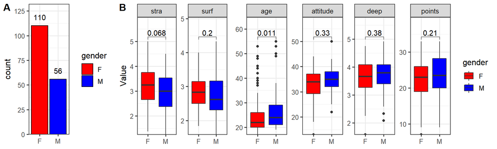

**Figure 1:** Basic plots for data exploration. **A)** Counts of data set subjects by gender. **B)** Box plots of the different variables.

```r
## generate a simple bar plot for counts of male and female subjects in the data set
p1 <- ggplot(dplyr::select(students2014, gender), aes(x=gender, fill=gender)) +
  geom_bar(colour="black") +
  ## expand the y-axis so that the count labels don't cut off
  scale_y_continuous(expand = expansion(mult = c(0, .2))) +
  geom_text(stat='count', aes(label=..count..), vjust=-1) +
  scale_fill_manual(values = c("red", "blue")) +
  theme_bw(12) +
  ## remove unnecessary x axis title
  theme(axis.title.x = element_blank())

## Plot normally distributed variables as bar plots and perform t.test using stat_compare_means
p2.n <- ggplot(dplyr::filter(to.ggplot, Variable %in% normal.values),
               aes(x = gender, y = Value, fill = gender, group=gender)) +
  geom_boxplot() +
  ## expand the y-axis so that the P-value labels don't cut off
  scale_y_continuous(expand = expansion(mult = c(0, .2))) +
  scale_fill_manual(values = c("red", "blue")) +
  ## Separate variables into different facets
  facet_wrap(~Variable, scales="free", nrow=1) +
  ## perform T-test
  stat_compare_means(comparisons = list(c("F","M")), method = "t.test", paired = FALSE) +
  theme_bw(12) +
  ## remove unnecessary legend  as it is in p2.nn
  ## remove unnecessary x axis title
  theme(legend.position = "none",
        axis.title.x = element_blank()) ## remove unnecessary legend  as it is in p2.nn

## Plot normally distributed variables as bar plots and perform t.test using stat_compare_means
p2.nn <- ggplot(dplyr::filter(to.ggplot, Variable %in% non.normal),
                aes(x = gender, y = Value, fill = gender, group=gender)) +
  geom_boxplot() +
  ## expand the y-axis so that the P-value labels don't cut off
  scale_y_continuous(expand = expansion(mult = c(0, .2))) +
  scale_fill_manual(values = c("red", "blue")) +
  ## Separate variables into different facets
  facet_wrap(~Variable, scales="free", nrow=1) +
   ## perform T-test
  stat_compare_means(comparisons = list(c("F","M")), method = "wilcox.test", paired = FALSE) +
  theme_bw(12) +
  ## remove unnecessary y-axis title as it is in p2.n
  ## remove unnecessary x axis title
  theme(axis.title.y = element_blank(),
        axis.title.x = element_blank())
## Combine plots with ggpubr's ggarrange() for labeling
ggarrange(p1, p2.n, p2.nn, labels = c("A", "B"), nrow=1, widths = c(1,1,2.3))
```

There are observations almost two times as many females in the data set as there are males (**Figure 1A**). Age seems to be the only variable that has different distribution between males and females, with males being higher aged (Wilcoxon P-value<0.05) (**Figure 1B**).

## Performing regression analysis for `points`

Now that we are familiar with the data set we can move on to regression modelling. We are going to use multiple regression to test how well test-`points` can be predicted using 3 variables from the data set (more information on multiple regression [here](https://www.datacamp.com/community/tutorials/linear-regression-R)). We can select the *e.g.* the variables with highest correlation with `points` for the fit. While we are at it we can plot all of the inter-variables correlations in our data set using `GGally::ggcor()`.

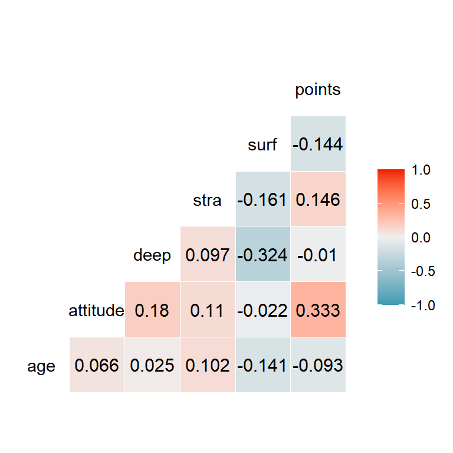

**Figure 2:** Correlation plot for the different variables

```r
## remove gender as it is not numeric and gives error
ggcorr(students2014[colnames(students2014) != "gender"], palette = "RdBu", label = TRUE, label_round=3)
```

Based on the results of the correlation analysis (**Figure 2**) we could use variables `stra`, `surf` and `attidute` for our explanatory variables for `points`. Lets build the model using `lm()` and view the summary of the results.

```r
lm.data <- lm(points ~ attitude + stra + surf, data = students2014)
summary(lm.data)
```

```
##
## Call:
## lm(formula = points ~ attitude + stra + surf, data = students2014)
##
## Residuals:
##      Min       1Q   Median       3Q      Max
## -17.7071  -3.3760   0.4279   3.6677  10.0219
##
## Coefficients:
##             Estimate Std. Error t value Pr(>|t|)
## (Intercept) 12.87300    3.98295   3.232  0.00149 **
## attitude     0.33976    0.07784   4.365 2.26e-05 ***
## stra         0.69501    0.56790   1.224  0.22280
## surf        -1.36841    0.82397  -1.661  0.09870 .
## ---
## Signif. codes:  0 '***' 0.001 '**' 0.01 '*' 0.05 '.' 0.1 ' ' 1
##
## Residual standard error: 5.524 on 162 degrees of freedom
## Multiple R-squared:  0.1378, Adjusted R-squared:  0.1218
## F-statistic: 8.627 on 3 and 162 DF,  p-value: 2.399e-05
```

Out of the variables used for fitting, only `attidute` seems to be a good addition to the model with -value < 2.26e-05. For every “global attitude toward statistics” point, exam points rise by ~0.34. Rest of the variables useed for the model did not reach significance (P-value<0.05), although with a looser cut-off (*e.g.* P-value<0.1) `surf` aka “Surface approach” seems to have negative impact on test score.

The model however, is quite unimpressive. Even though it is statistically significant (the independent variables explain the dependent variable, P-value<2.399e-05) it does not explain a lot of the whole situation. R<sup>2</sup> value can be used to asses how good the model is at explaining the variability in the data. R<sup>2</sup> is calculated in the following manner:

$$R^2 = \frac{\text{Explained variation of the model}}{\text{Total variation of the model}}$$

The higher the R<sup>2</sup> (closer to 1) the better. The multiple R<sup>2</sup> of the model is a measly 0.1378 which means that the current model fails to predict most of the variability (predicts ~14% of it). In summary, the model explains the dependent variable but only on a small scale.

## Assessing the quality of the model

We can now assess the models validity by plotting some diagnostic plots.

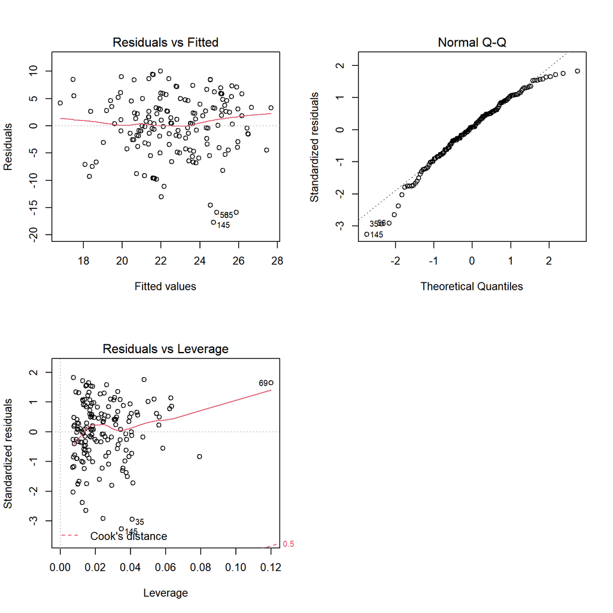

**Figure 3:** Plots for Residuals vs Fitted values, Normal QQ-plot and Residuals vs Leverage

```r
par(mfrow = c(2,2))
plot(lm.data, which=c(1,2,5))
```

From **Figure 3 “Residuals vs Fitted”** plot we can see that there are no worrying trends apparent in the plot. This suggest that we can assume linear relationship between dependent and independent variables. In **Figure 3 “Normal Q-Q”** plot we see that the points follow the reference line quite nicely and thus we can assume normality. In **Figure 3” Residuals vs Leverage”** we can see that there are no influential points (observations that affects the coefficients in the model summary drastically). If there were influential points we should pin-point the cause behind the outlier and possibly even remove it (if it is from erroneous measurement etc.).

```r
# Date and session info
date()
```

```
## [1] "Mon Nov 15 03:22:41 2021"
```